# 1. Statistics

## 3.3. Low Rank Approximation: Dimension Reduction

### 3.3.1. Low Rank Approximation

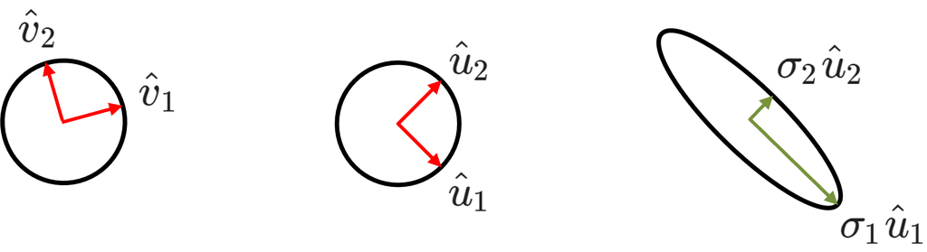

In the 2D case, consider a vector $x$ that can be expressed in terms of the basis vectors $v_1$ and $v_2$ (where $\hat v$ denotes a unit vector, though this notation is omitted here for simplicity):

$$x = c_1 v_1 + c_2 v_2$$

Equivalently,

$$x = \langle x, v_1 \rangle v_1 + \langle x, v_2 \rangle v_2$$

Since inner products can be rewritten in matrix notation,

$$x = ( v_1^{T} x) v_1 + ( v_2^T x) v_2$$

**SVD Transformation**

Next, consider the effect of matrix $A$ on the vector $x$:

$$Ax = c_1 A v_1 + c_2 A v_2$$

By the SVD property,

$$A v_1 = \sigma_1 u_1 \quad \text{and} \quad A v_2 = \sigma_2 u_2$$

Thus,

$$Ax = c_1 \sigma_1 u_1 + c_2 \sigma_2 u_2$$

Equivalently,

$$ \begin{align*} Ax &= u_1 \sigma_1 v_1^T x + u_2 \sigma_2 v_2^T x \\ & = \begin{bmatrix} u_1 & u_2 \end{bmatrix}\begin{bmatrix}\sigma_1 & 0\\ 0 & \sigma_2 \end{bmatrix}\begin{bmatrix} v_1^T \\ v_2^T \end{bmatrix} x\\ & = \begin{bmatrix} u_1 & u_2 \end{bmatrix}\begin{bmatrix}\sigma_1 & 0\\ 0 & \sigma_2 \end{bmatrix}\begin{bmatrix} v_1 & v_2 \end{bmatrix}^T x \end{align*} $$

In matrix form,

$$Ax = U \Sigma V^T x$$

**Low-Rank Approximation in General**

In practice, if one singular value dominates the others ($\sigma_1 \gg \sigma_2$), we can approximate $A$ with a rank-1 approximation:

$$Ax = u_1 \sigma_1 v_1^T x + u_2 \sigma_2 v_2^T x \approx u_1 \sigma_1 v_1^T x$$

**General Low-Rank Approximation of Matrix $A$**

For a general matrix $A$, the SVD decomposition allows for constructing a low-rank approximation by retaining only the top $k$ singular values:

- Full-rank representation:

$$ A = U_r \Sigma_r V_r^T = \sum_{i=1}^{r} \sigma_i u_i v_i^T $$

- Rank-$k$ approximation (with $k \leq r$):

$$ \tilde{A} = U_k \Sigma_k V_k^T = \sum_{i=1}^{k} \sigma_i u_i v_i^T $$

**Example: Matrix**

```python
A = np.array([[11.08, 6.82, 1.76, -6.82],
              [2.50, -1.01, -2.60, 1.19],
              [-4.88, -5.07, -3.21, 5.20],
              [-0.49, 1.52, 2.07, -1.66],
              [-14.04, -12.40, -6.66, 12.65],
              [0.27, -8.51, -10.19, 9.15],
              [9.53, -9.84, -17.00, 11.00],
              [-12.01, 3.64, 11.10, -4.48]])
```

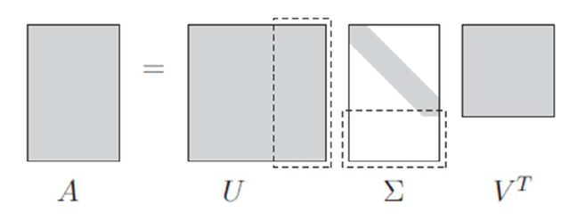

```python
[U, S, VT] = np.linalg.svd(A, full_matrices = True)

U = np.asmatrix(U)
S = np.asmatrix(np.diag(S))
VT = np.asmatrix(VT)

print(U.shape, S.shape, V.shape, '\n')
print(U, '\n')
print(S, '\n')
print(VT)
```

```
(8, 8) (4, 4) (2, 2)

[[-0.24642369  0.44536234  0.6205749   0.32739909  0.45915182  0.05410587
  -0.18650735  0.00956801]
 [ 0.07432183  0.10750102  0.28337342 -0.77803389 -0.10352762  0.32547077
  -0.42245245  0.04655432]
 [ 0.21369502 -0.1903207   0.49492174  0.11043549 -0.4736735  -0.61498898
  -0.24132713 -0.01233476]
 [-0.08223154 -0.02472167  0.20057294  0.06152361 -0.27047805  0.29819169
   0.20131309 -0.86371786]
 [ 0.50375686 -0.55378628  0.13739629 -0.02351069  0.61002316  0.01682912
  -0.07593043 -0.20479838]
 [ 0.43719294  0.03496575 -0.05496539  0.50172005 -0.29664823  0.55199001
  -0.3572128   0.18055856]
 [ 0.59019451  0.42657675  0.21078205 -0.13667122 -0.03298713 -0.00394525
   0.6243326   0.1252985 ]
 [-0.2967926  -0.51321848  0.42787997  0.0231769  -0.14042827  0.34499254
   0.40598717  0.40166774]]

[[3.68258450e+01 0.00000000e+00 0.00000000e+00 0.00000000e+00]
 [0.00000000e+00 2.62368811e+01 0.00000000e+00 0.00000000e+00]
 [0.00000000e+00 0.00000000e+00 2.20213307e-02 0.00000000e+00]
 [0.00000000e+00 0.00000000e+00 0.00000000e+00 5.10429562e-03]]

[[-0.03564832 -0.5381828  -0.61426544  0.5759917 ]
 [ 0.92076022  0.16617467 -0.32597333 -0.13538086]
 [-0.13920696 -0.49222525 -0.31155848 -0.80079151]
 [-0.36269992  0.66367127 -0.6475729  -0.09294376]]
```

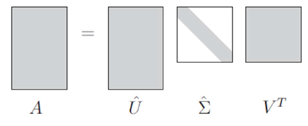

```python
[U, S, VT] = np.linalg.svd(A, full_matrices = False)

U = np.asmatrix(U)
S = np.asmatrix(np.diag(S))
VT = np.asmatrix(VT)

print(U.shape, S.shape, V.shape, '\n')
print(U, '\n')
print(S, '\n')
print(VT)
```

```
(8, 4) (4, 4) (2, 2)

[[-0.24642369  0.44536234  0.6205749   0.32739909]
 [ 0.07432183  0.10750102  0.28337342 -0.77803389]
 [ 0.21369502 -0.1903207   0.49492174  0.11043549]
 [-0.08223154 -0.02472167  0.20057294  0.06152361]
 [ 0.50375686 -0.55378628  0.13739629 -0.02351069]
 [ 0.43719294  0.03496575 -0.05496539  0.50172005]
 [ 0.59019451  0.42657675  0.21078205 -0.13667122]
 [-0.2967926  -0.51321848  0.42787997  0.0231769 ]]

[[3.68258450e+01 0.00000000e+00 0.00000000e+00 0.00000000e+00]
 [0.00000000e+00 2.62368811e+01 0.00000000e+00 0.00000000e+00]
 [0.00000000e+00 0.00000000e+00 2.20213307e-02 0.00000000e+00]
 [0.00000000e+00 0.00000000e+00 0.00000000e+00 5.10429562e-03]]

[[-0.03564832 -0.5381828  -0.61426544  0.5759917 ]
 [ 0.92076022  0.16617467 -0.32597333 -0.13538086]
 [-0.13920696 -0.49222525 -0.31155848 -0.80079151]
 [-0.36269992  0.66367127 -0.6475729  -0.09294376]]
```

**Question**

How to determine a good $k$ so that we can efficiently compress $A$ without losing too much information of $A$?

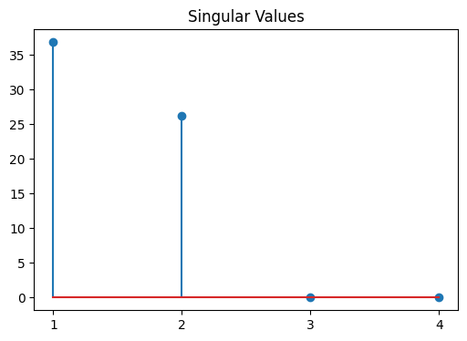

```python
sig_val = np.diag(S)

plt.figure(figsize = (6, 4))
plt.stem(range(1,5), sig_val)
plt.xticks(range(1,5))
plt.title('Singular Values')
plt.show()
```

When singular values decay rapidly, retaining only the top $k$ singular values can provide an accurate yet efficient approximation.

```python
k = 2

low_U = U[:, :k]
low_S = S[:k, :k]
low_VT = VT[:k, :]

A_approx = low_U*low_S*low_VT

print(low_U.shape, low_S.shape, low_VT.shape, '\n')
print('A:\n', A ,'\n')
print('A_approx:\n', A_approx, '\n')
print('low_U:\n', low_U, '\n')
print('low_VT:\n', low_VT)
```

```
(8, 2) (2, 2) (2, 4)

A:
 [[ 11.08   6.82   1.76  -6.82]
 [  2.5   -1.01  -2.6    1.19]
 [ -4.88  -5.07  -3.21   5.2 ]
 [ -0.49   1.52   2.07  -1.66]
 [-14.04 -12.4   -6.66  12.65]
 [  0.27  -8.51 -10.19   9.15]
 [  9.53  -9.84 -17.    11.  ]
 [-12.01   3.64  11.1   -4.48]]

A_approx:
 [[ 11.08250851   6.8256176    1.76533991  -6.80890115]
 [  2.49942829  -1.00429274  -2.60062751   1.19462804]
 [ -4.87827835  -5.06500943  -3.20623934   5.20878009]
 [ -0.48927124   1.52196569   2.07157948  -1.65643381]
 [-14.03962233 -12.39843105  -6.65913505  12.65241176]
 [  0.27076035  -8.51229541 -10.18871873   9.14926874]
 [  9.53039313  -9.83725225 -16.99900559  11.0036522 ]
 [-12.00864542   3.64455947  11.10301226  -4.47244356]]

low_U:
 [[-0.24642369  0.44536234]
 [ 0.07432183  0.10750102]
 [ 0.21369502 -0.1903207 ]
 [-0.08223154 -0.02472167]
 [ 0.50375686 -0.55378628]
 [ 0.43719294  0.03496575]
 [ 0.59019451  0.42657675]
 [-0.2967926  -0.51321848]]

low_VT:
 [[-0.03564832 -0.5381828  -0.61426544  0.5759917 ]
 [ 0.92076022  0.16617467 -0.32597333 -0.13538086]]
```

### 3.3.2. Visual Illustration

Full SVD

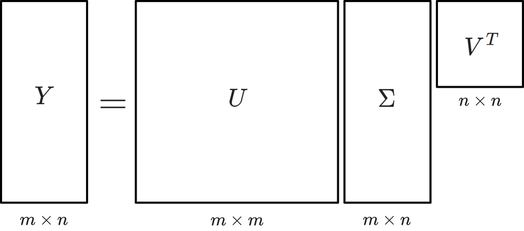

Thin (or Economy) SVD

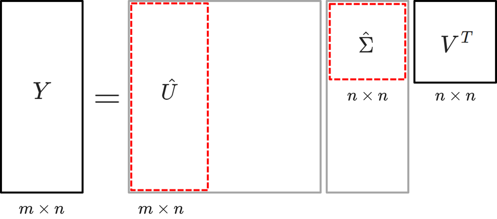

Truncated SVD (Low Rank Approximation)

$$Y \approx U_r \Sigma_r V_r^T$$

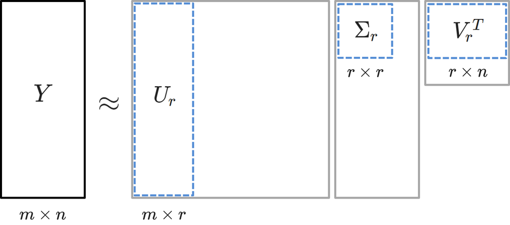

- First term

$$Y_1 \approx u_1 \sigma_1 v_1^T$$

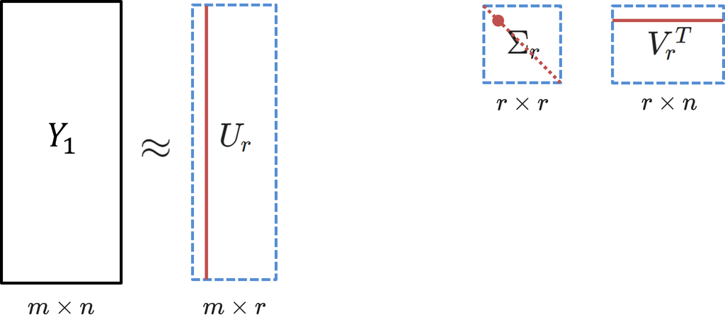

- Second term

$$Y_2 \approx u_2 \sigma_2 v_2^T$$

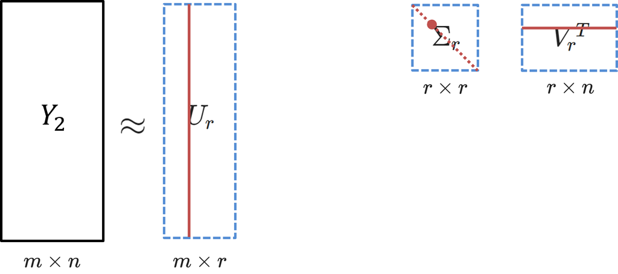

- Third term

$$Y_3 \approx u_3 \sigma_3 v_3^T$$

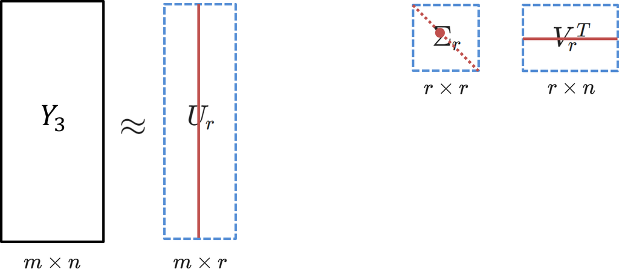

- Best approximation with a finite $r$ decompositions

$$Y \approx Y_1 + Y_2 + Y_3 + \cdots = u_1 \sigma_1 v_1^T + u_2 \sigma_2 v_2^T + u_3 \sigma_3 v_3^T + \cdots = \sum_{j = 1}^{r} u_j \sigma_j v_j^T$$

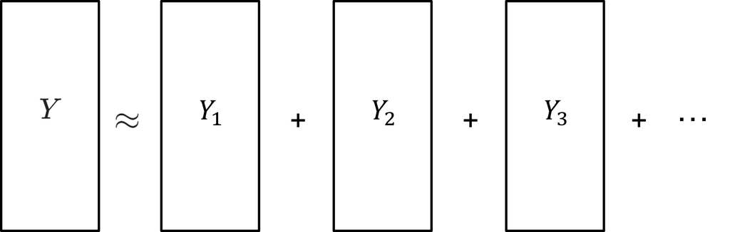

### 3.3.3. Example: Image Approximation

**Image as a Matrix**

An image can be represented as a matrix $A$, where each entry corresponds to the intensity of a pixel for grayscale images. By applying SVD, we decompose the image matrix as follows:

$$A = U\Sigma V^T$$

**Image Approximation with Rank-$k$ Decomposition**

Instead of retaining the full rank of $A$, we can approximate it using only the top $k$ singular values:

$$\tilde A = U_k \Sigma_k V_k^T = \sum_{i=1}^{k}\sigma_i u_i v_i^T \qquad (k \leq r)$$

Downlaod the [image file](https://drive.google.com/file/d/1-qr6_sp74f-xhFn8sCZpGiDmGOT_FWai/view?usp=sharing)

```python
from google.colab import drive
drive.mount('/content/drive')
```

```python
import cv2

img = cv2.imread('/content/drive/MyDrive/ML/ML_data/kaist_me.jpg', 0)
print(img.shape)
```

```
(1459, 2593)
```

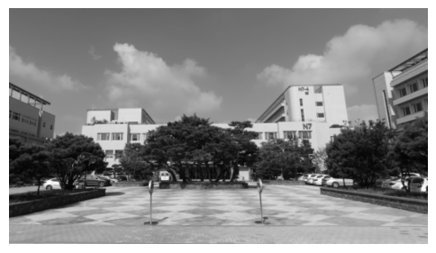

```python
plt.figure(figsize = (6, 6))
plt.imshow(img, 'gray')
plt.axis('off')
plt.show()
```

**SVD**

```python
A = img

[U, S, VT] = np.linalg.svd(A, full_matrices = False)

U = np.asmatrix(U)
S = np.asmatrix(np.diag(S))
VT = np.asmatrix(VT)

print(U.shape, S.shape, VT.shape, '\n')
```

```
(1459, 1459) (1459, 1459) (1459, 2593)
```

**Plot Singular Values**

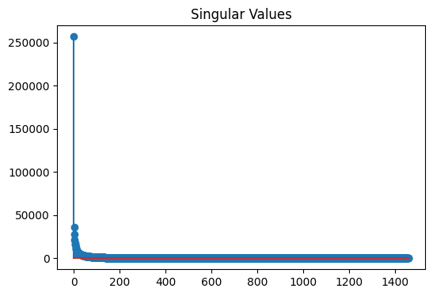

```python
sig_val = np.diag(S)

plt.figure(figsize = (6, 4))
plt.stem(sig_val)
plt.title('Singular Values')
plt.show()
```

**Approximated image when $k = 20$**

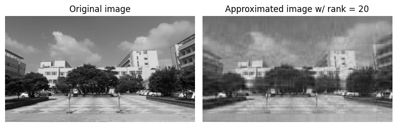

```python
k = 20

low_U = U[:, :k]
low_S = S[:k, :k]
low_VT = VT[:k, :]

A_hat = low_U*low_S*low_VT

plt.figure(figsize = (8, 5))
plt.subplot(1,2,1)
plt.imshow(A, 'gray')
plt.axis('off')
plt.title('Original image')

plt.subplot(1,2,2)
plt.imshow(A_hat, 'gray')
plt.axis('off')
plt.title('Approximated image w/ rank = 20')

plt.tight_layout()
plt.show()
```

**Approximated images with $k$ varied**

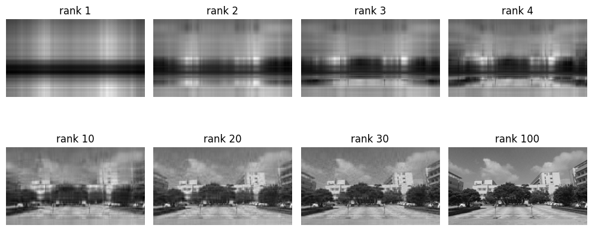

```python
K = [1, 2, 3, 4, 10, 20, 30, 100]

plt.figure(figsize = (10, 5))

for i in range(len(K)):
    low_U = U[:, :K[i]]
    low_S = S[:K[i], :K[i]]
    low_VT = VT[:K[i], :]

    A_hat = low_U*low_S*low_VT

    plt.subplot(2,4,i+1), plt.imshow(A_hat, 'gray'), plt.axis('off')
    plt.title('rank {}'.format(K[i]))

plt.tight_layout()
plt.show()
```

**Discussion**

Each image is reconstructed using a progressively higher rank approximation, capturing increasing levels of detail.

(1) Rank 1 Image:

- Captures only the most dominant pattern or trend in the image - primarily the strongest intensity gradients (e.g., horizontal patterns or key contrast areas).
- This is because the first singular value and its corresponding singular vectors dominate the overall structure.

(2) Rank 2 to Rank 4 Images:

- As the rank increases, additional singular values and vectors are included, allowing finer details like outlines and texture to emerge.

(3) Rank 10 to Rank 30 Images:

- The image progressively becomes clearer, with sharper details and improved accuracy.

(4) Rank 100 Image:

- The reconstruction is almost identical to the original image, indicating that a significant portion of the visual information is retained.

**Image Compression Using Low-Rank Approximation with SVD**

Suppose a satellite captures an image that needs to be transmitted to the ground station. Given the constraints of limited communication bandwidth, it becomes crucial to minimize the amount of transmitted data without significant loss of image quality. In this scenario, low-rank approximation using SVD offers an effective solution.

Instead of transmitting the entire matrix $A$, we only transmit:

- The first $k$ columns of $U$
- The first $k$ singular values in $\Sigma$
- The first $k$ rows of $V^T$

The transmitted data is significantly smaller:

- Original data size: $m \times n$
- Compressed data size: $k (m + 1 + n)$

### 3.3.4. Example: Extracting Background from Sequential Images

This example demonstrates how SVD can effectively isolate the background from a series of video frames by leveraging low-rank approximation. The objective is to remove moving objects (people) from the images while preserving the static background.

The dataset consists of 20 sequential images (or frames) captured from a video showing people walking. These images contain both dynamic (moving) elements and a static background. By applying SVD, we aim to identify and extract the dominant structure - the background - while minimizing the impact of moving objects.

- Example Source: [Medium article](https://medium.com/@mubashir_ul_islam/background-extraction-from-surveillance-camera-using-singular-value-decomposition-svd-c7c9cff4dc84)
- Dataset: [Download and unzip data](https://drive.google.com/file/d/1EAYsCosYTQfgX85bc2DvlctLQBEDBLir/view?usp=sharing)

**Step 1: Display the Images**

A video of people walking, captured by a surveillance camera

```python
from IPython.display import YouTubeVideo
YouTubeVideo('-5R2yvPsbmo', width = "560", height = "315")
```

[video not shown]

Capture each frame as an image

```python
from google.colab import drive
drive.mount('/content/drive')
```

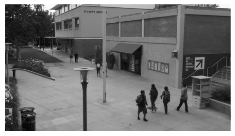

```
(338, 600)
```

```python
import numpy as np
import cv2
import matplotlib.pyplot as plt
%matplotlib inline

# Plot the first 'capimage_0.jpg' image in grayscale.

data_path = '/content/drive/MyDrive/ML/ML_data'
img = cv2.imread(data_path + '/capimage_0.jpg', 0)

plt.figure(figsize = (6, 4))
plt.imshow(img, 'gray')
plt.axis('off')
plt.show()

print(img.shape)
```

[figure not shown]

```python
# Plot the sequential 6 images in grayscale.

plt.figure(figsize = (8, 4))

for i in range(6):
  img_name = ['capimage_' + str(i) + '.jpg']
  img = cv2.imread(data_path + '/' + img_name[0], 0)
  plt.subplot(2, 3, i+1)
  plt.imshow(img, 'gray')
  plt.title(img_name[0], fontsize = 12)
  plt.axis('off')

plt.tight_layout()
plt.show()
```

**Step 2: Construct Matrix $A$**

In the previous example, an image was represented as a matrix $A$, allowing us to apply SVD for low-rank approximation. However, in this example, we are dealing with 20 images, each represented as its own matrix. This introduces a new challenge: how to efficiently apply SVD to multiple image matrices simultaneously.

The brilliant (yet conceptually straightforward) idea is to flatten each image into a column vector and then horizontally stack these vectors to construct a new matrix $A$. This consolidated matrix enables us to apply SVD efficiently.

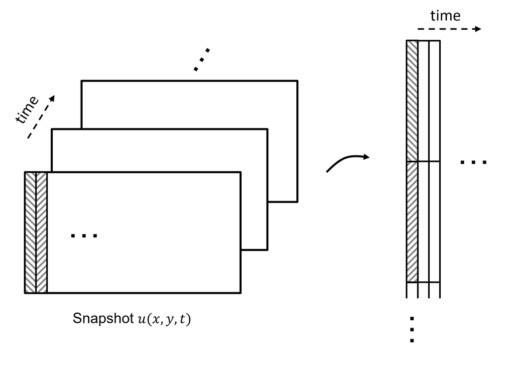

At first glance, you might hesitate since flattening seemingly disrupts the inherent spatial structure of the images. Surprisingly, however, it works well!

- Load all 20 grayscale images.
- Reshape each image into a column vector of shape $(\text{row} \times \text{col},1)$.
- Horizontally stack these vectors to form matrix $A$, resulting in a shape of:

$$A \in \mathbb{R}^{(\text{row} \times \text{col})\times 20}$$

```python
flat_img = []

for i in range(20):
  img = cv2.imread(data_path + '/capimage_' + str(i) + '.jpg', 0)
  flat_img = img.reshape(-1, 1)
  if i == 0:
    A = flat_img
  else:
    A = np.hstack((A, flat_img))

row = img.shape[0]
col = img.shape[1]

print(row)
print(col)
print(A.shape)
```

```
338
600
(202800, 20)
```

**Step 3: Compute SVD and Visualize Sigular Values**

```
(202800, 20) (20, 20) (20, 20)
```

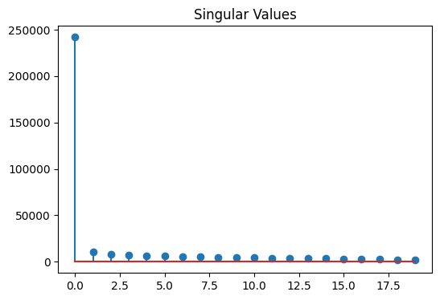

```python
U, S, VT = np.linalg.svd(A, full_matrices = False)
U = np.asmatrix(U)
S = np.asmatrix(np.diag(S))
VT = np.asmatrix(VT)

print(U.shape, S.shape, VT.shape, '\n')

plt.figure(figsize = (6, 4))
plt.stem(np.diag(S))
plt.title('Singular Values')
plt.show()
```

**Step 4: Low-Rank Approximation with $k = 1$**

Using only the first singular value, reconstruct the background using the formula:

$$\hat{A} = U_k \Sigma_k V_k^T = \sigma_1 u_1 v_1^T$$

- Extract the first column of $\hat A$, which corresponds to the reconstructed background of the first frame.
- Reshape it back to its original image dimensions and display the result.

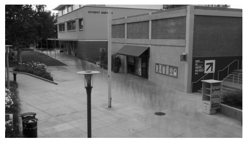

```python
# Plot A_hat[:,0] with a reshape of (row, col)

A_hat = U[:,0] * S[0,0] * VT[0,:]

plt.figure(figsize = (6, 8))
plt.imshow(A_hat[:, 0].reshape(row, col), 'gray')
plt.axis('off')
plt.show()
```

**Discussion**

- The first singular component captures the most dominant pattern across all frames - in this case, the stationary background.
- Moving objects (like people walking) are treated as noise or high-frequency variations and are effectively removed by the low-rank approximation.
- This is an impressive example. I personally had never envisioned such an innovative approach to effectively remove moving objects from images.

## 3.4. Eigenfaces: A SVD-Based Facial Recognition Technique

[Eigenfaces](http://en.wikipedia.org/wiki/Eigenface) is a well-known technique in computer vision that applies PCA or SVD for facial recognition. The method is based on the idea that faces can be represented as combinations of key facial features, called eigenfaces. By leveraging SVD, Eigenfaces effectively reduces the dimensionality of face images while retaining the most important features for identification.

$$ \tilde{x} = \sum_{i=1}^{k} \langle x,\hat{u}_i\rangle \,\hat{u}_i $$

Concept of Eigenfaces

The key idea behind Eigenfaces is that any face can be represented as a linear combination of a set of “basis” faces - the eigenfaces - which capture the most dominant features in the dataset.

Given a set of face images:

- Each face is reshaped into a column vector.
- These column vectors are stacked horizontally to form a matrix $A$.

$$ A = \begin{bmatrix} | & | & \cdots & | \\ x_1 & x_2 & \cdots & x_n \\ | & | & \cdots & | \end{bmatrix} $$

Where:

- Each $x_i$ is a reshaped image vector.
- $A \in \mathbb{R}^{(m \times n)}\; (m \gg n) $, where $m$ is the total number of pixels in each image and $n$ is the total number of images.

In this example, we will use a set of 12 images of U.S. Presidents to demonstrate the concept of Eigenfaces.

- Download the [face file](https://drive.google.com/file/d/1P-JEzml1rTorUAWLs66gctQaE0Tg0HCT/view?usp=sharing)

```python
from google.colab import drive
drive.mount('/content/drive')
```

```python
import numpy as np
from scipy import io
import matplotlib.pyplot as plt
%matplotlib inline

faces = io.loadmat('/content/drive/MyDrive/ML/ML_data/faces.mat')
face_mat = faces['faces']
```

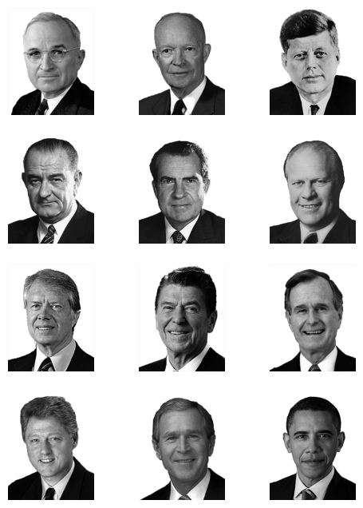

```python
row, col, n = face_mat.shape

plt.figure(figsize = (6, 8))

for i in range(n):
    plt.subplot(4, 3, i+1), plt.axis('off')
    plt.imshow(face_mat[:, :, i], 'gray')

plt.show()
```

Build matrix $A$ out of 12 images

$$ A = \begin{bmatrix} | & | & \cdots & | \\ x_1 & x_2 & \cdots & x_n \\ | & | & \cdots & | \end{bmatrix} $$

```python
A = np.reshape(face_mat, [row*col, n])
```

**Compute the Eigenfaces Using SVD**

Given a set of facial images stored as matrix $A$, compute the SVD:

$$A = U \Sigma V^T$$

Where:

- $U$: Left singular vectors (**the eigenfaces**).
- $\Sigma$: Diagonal matrix containing the **singular values**.
- $V$: Right singular vectors representing the **coefficients (weights)**.

```python
[U, S, VT] = np.linalg.svd(A, full_matrices = False)

U = np.asmatrix(U)
S = np.asmatrix(np.diag(S))
VT = np.asmatrix(VT)

print(U.shape, S.shape, VT.shape, '\n')
```

```
(50000, 12) (12, 12) (12, 12)
```

**Eigenface or eigenmode from $U$**

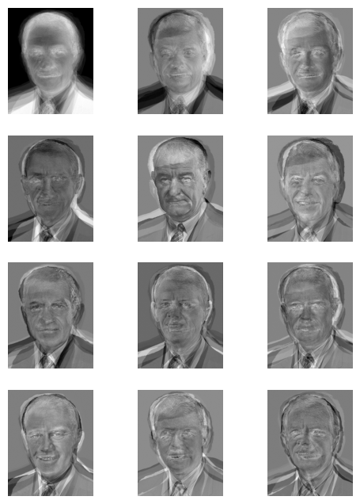

```python
plt.figure(figsize = (6, 8))

for i in range(n):
    plt.subplot(4, 3, i+1), plt.axis('off')
    plt.imshow(U[:, i].reshape(row, col), 'gray')

plt.show()
```

**Singular values**

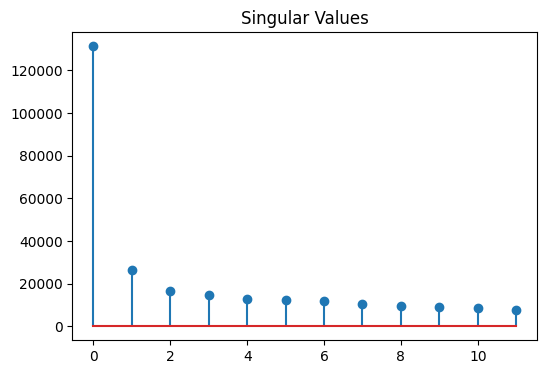

```python
sig_val = np.diag(S)

plt.figure(figsize = (6, 4))
plt.stem(sig_val)
plt.title('Singular Values')
plt.show()
```

### 3.4.1. Data Compression

**Transmit the compressed information**

- Assume that both parties have eigenfunctions
- Only thing to transmit is the corresponding weights of the eigenfunctions

**Encode the Image Using Weights**

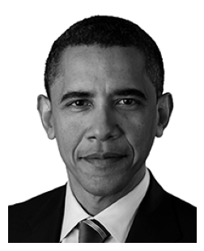

```python
obama = face_mat[:,:,11]

plt.figure(figsize = (3, 4))
plt.imshow(obama, 'gray')
plt.axis('off')
plt.show()
```

**Transmit the Encoded Data**

For a given image $x$, project the image onto the eigenface basis:

$$z = U^T x$$

Where:

- $z$ is the **vector of coefficients (weights)** that encodes the original image in the reduced-dimensional subspace.
- This encoding drastically reduces the data size since $z$ typically requires far fewer values than the original image.

Instead of transmitting the entire image $x$, only the coefficient vector $z$ is transmitted. The vector $z$ is smaller in size because the SVD retains only the most significant features, discarding noise or less important details.

```python
# sender
x = np.reshape(obama, [row*col, 1])
eigenface_decom = U.T*x

print(eigenface_decom)
```

```
[[-37117.28758117]
 [ -1854.11277302]
 [  4846.84543325]
 [  7876.39630423]
 [  -873.87825574]
 [  -450.54219688]
 [  1218.84905328]
 [ -5629.177794  ]
 [ -3180.2611649 ]
 [ -2436.0983698 ]
 [  1741.91910063]
 [  -438.24812691]]
```

**Reconstruct the Image at the Receiver’s End**

At the receiver’s end, reconstruct the original image using the transmitted coefficient vector:

$$\hat{x} = U z$$

Where:

- $\hat{x}$ is the reconstructed image.
- The quality of the reconstructed image depends on the number of retained coefficients (corresponding to the **rank $k$**).

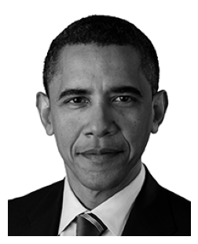

```python
# receiver
reconst = U*eigenface_decom

plt.figure(figsize = (3, 4))
plt.imshow(reconst.reshape(row, col), 'gray')
plt.axis('off')
plt.show()
```

**Choosing the Rank $k$ for Reconstruction**

- **Large $k$** → Higher quality with more detail, but larger data size.
- **Small $k$** → Lower data size, but reduced image quality.

In practice, selecting an optimal $k$ balances compression efficiency with visual quality.

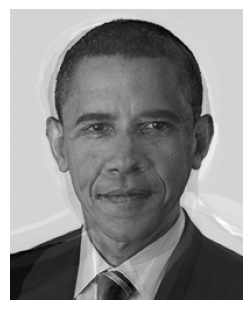

```python
k = 9

# sender
x = np.reshape(obama, [row*col, 1])
eigenface_decom = U[:,:k].T*x

# reciever
reconst = U[:,:k]*eigenface_decom

plt.figure(figsize = (3, 4))
plt.imshow(reconst.reshape(row, col), 'gray')
plt.axis('off')
plt.show()
```

**Discussion**

- SVD efficiently separates meaningful facial features from noise.
- Encoding the image as coefficients (weights) significantly reduces the transmitted data.
- The method achieves excellent compression without severe loss of image quality.
- $U$ contains the eigenmodes.

### 3.4.2. Face Recognition Using Eigenfaces

The Eigenfaces method is a classical yet effective technique for **face recognition**. While modern deep learning methods dominate large-scale face recognition tasks, Eigenfaces with SVD remains practical for scenarios with limited data or controlled environments.

Step 1: Project Image onto the Eigenface Subspace

- Given an unseen input face image $x$, project it onto the eigenface subspace:

$$z = U^T x$$

Where:

- $z$ is the vector of **projected coefficients** (or weights) that represents the image in the reduced-dimensional space.
- $U$ contains the **eigenmodes** (eigenfaces) computed via SVD.

Step 2: Face Identification Using Distance Metrics

- For each new input image, compute its coefficient vector $z$.
- Compare $z$ with the coefficient vectors stored in the training set.
- The most common method for comparison is the **Euclidean distance**:

$$d(x, x_i) = \lVert z - z_i \rVert_2$$

Where:

- $z_i$ is the coefficient vector for the $i$-th individual in the training set.

Step 3: Classification Decision

- The identity of the input face is determined by finding the **closest match** in the training set:

$$\hat{i} = \arg \min_i \; \lVert z - z_i \rVert_2$$

**When is the Eigenface Method Preferred Over Deep Learning?**

Although deep learning dominates face recognition tasks today, Eigenfaces is particularly useful in the following scenarios:

- Limited Data: When only a small dataset is available (e.g., internal employee database).
- Controlled Environments: In secure workplaces or facilities where environmental conditions are consistent.
- Cost Efficiency: Suitable for applications with limited computational resources.
- Simple Implementation: Requires no complex neural network architecture.

**Practical Example**

Suppose you need to build a face recognition system for identifying employees in your company:

- Collect face images of all employees and compute their projected coefficients using the eigenface method.
- When a person enters the building, compute the projected coefficients for their image.
- Compare these coefficients with those stored in the database using Euclidean distance.
- If the closest match is below a predefined threshold, the individual is recognized as an employee; otherwise, access may be denied.

### 3.4.3. Recognition and Reconstruction of Disguised Face

Here, I present an interesting scenario: President John F. Kennedy is wearing sunglasses when he enters the White House.

Download the [image file](https://drive.google.com/file/d/1hWuELIH6BrM_5WG_WORTMT5Zfjr1Tve3/view?usp=sharing)

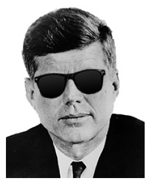

```python
import cv2

jfk = cv2.imread('/content/drive/MyDrive/ML/ML_data/jfk.png', 0)

plt.figure(figsize = (3, 4))
plt.imshow(jfk, 'gray')
plt.axis('off')
plt.show()
```

Although our database contains his face image without sunglasses, our system must still successfully recognize him. Let's see how we can achieve this.

```python
# projected coeeficient for new face
x = np.reshape(jfk, [row*col, 1])
eigenface_decom = U.T*x

# compute Euclidean distance to all training set
distances = []

for i in range(A.shape[1]):
  train_image_decomposition = U.T @ A[:, i].reshape(-1, 1)
  distance = np.linalg.norm(eigenface_decom - train_image_decomposition)
  distances.append(distance)


argmin_index = np.argmin(distances)

print(f"The input image is most similar to training image {argmin_index}")
```

```
The input image is most similar to training image 2
```

We can go even further.

Using the low-rank approximation properties of SVD, we can reconstruct his face by emphasizing dominant features while filtering out subtle variations, such as sunglasses.

This method effectively reveals the underlying facial structure, demonstrating how SVD can be used not only for recognition but also for image reconstruction and enhancement.

**Projection onto $U$ and Reconstruct**

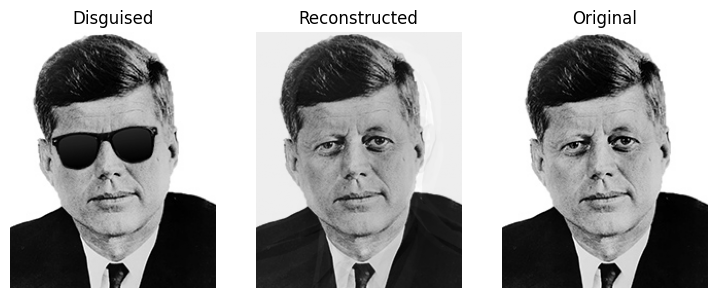

```python
x = np.reshape(jfk, [row*col, 1])

eigenface_decom = U.T*x
reconst = U*eigenface_decom

plt.figure(figsize = (9, 4))

plt.subplot(1,3,1)
plt.imshow(jfk, 'gray')
plt.title('Disguised')
plt.axis('off')

plt.subplot(1,3,2)
plt.imshow(reconst.reshape(row, col), 'gray')
plt.title('Reconstructed')
plt.axis('off')

plt.subplot(1,3,3)
plt.imshow(A[:,2].reshape(row, col), 'gray')
plt.title('Original')
plt.axis('off')

plt.show()
```

# 4. Proper Orthogonal Decomposition (POD)

The Proper Orthogonal Decomposition (POD) is a powerful method used to analyze data that varies across both space and time. This technique effectively identifies dominant patterns within complex systems and is widely used in fields such as fluid dynamics, structural mechanics, and signal processing.

Suppose we have data that is a function of both space and time:

$$y(x,t)$$

Our objective is to decompose this system into its fundamental building blocks.

A natural starting point is to express the system using a separation of variables approach:

$$y(x,t) = \sum_{j = 1}^{r}u_j(x) a_j(t)$$

Where

- $u_j(x)$ represents spatial modes (basis functions)
- $a_j(t)$ represents time-dependent coefficients (weights)

We aim to approximate most of the data using the smallest number of terms $r$.

**Arrangement of Data**

To implement POD efficiently, we organize the data into a matrix form:

- Suppose measurements are taken at spatial locations $x_1, x_2, \cdots, x_n$
- Suppose measurements are recorded at times $t_1, t_2, \cdots, t_m$
- (typically after first subtracting a mean or equilibrium state)

We can construct a data matrix $Y$ with shape $n \times m$

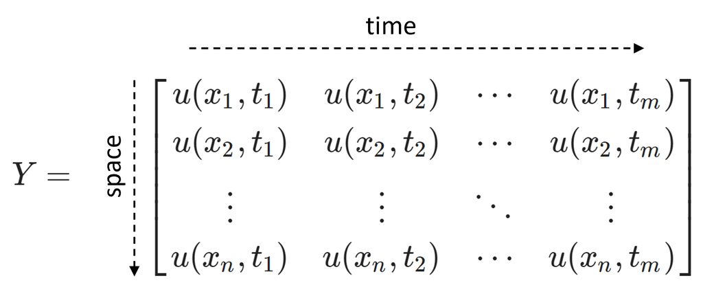

**POD Algorithm**

$$ \begin{align*} Y_r &= U_r \Sigma_r V^T_r \\ &= \sum^{r}_{j=1}u_j \; \sigma_j v_j^T \\ & = \sum^{r}_{j=1}u_j(x) \; \sigma_j v_j(t)^T = \sum^{r}_{j=1}u_j (x) a_j(t) \end{align*} $$

This decomposition can be interpreted as:

- $u_j(x)$: Spatial mode that represents dominant spatial features.
- $a_j(t) = \sigma_j v_j(t)$: Temporal coefficient that describes the corresponding dynamic behavior.

## 4.1. Example 1

$$y(x,t) = \sin(\omega t - k x) + \varepsilon $$

**Data Arrangement**

```python
import numpy as np
import matplotlib.pyplot as plt
%matplotlib inline

# data generated from the function

x = np.linspace(0, 5, 200)
Nx = np.size(x)

dt = 0.01
t = np.arange(0, 1, dt)

k = 2
omega = 4*np.pi

Y = np.zeros([np.size(x), np.size(t)], dtype = 'd')

for i in range(0, np.size(x)):
  for j in range(0, np.size(t)):
    Y[i, j] = np.sin(omega*t[j] - k*x[i]) + 0.1*np.random.randn()

print(Y.shape)
```

```
(200, 100)
```

**Plot**

```python
# Let's see the signal in time

from matplotlib.animation import FuncAnimation
import time
from IPython import display

fig = plt.figure(figsize = (6, 4))
ax1 = fig.add_subplot(1, 1, 1)

def animate(i):
  ax1.clear()
  ax1.plot(x, Y[:,i], linewidth = 2)
  ax1.set_xlabel('x')
  ax1.set_xlim(0, 5)
  ax1.set_ylim(-2, 2)
  ax1.grid()

ani = FuncAnimation(fig, animate, frames = int(np.size(t)/1), interval = 10)
video = ani.to_html5_video()
html = display.HTML(video)
display.display(html)
plt.close()
```

[video not shown]

**Perform the SVD**

```python
U, S, VT = np.linalg.svd(Y, full_matrices = False)

print(U.shape)
print(S.shape)
print(VT.shape)
```

```
(200, 100)
(100,)
(100, 100)
```

**Plot the Singular Values**

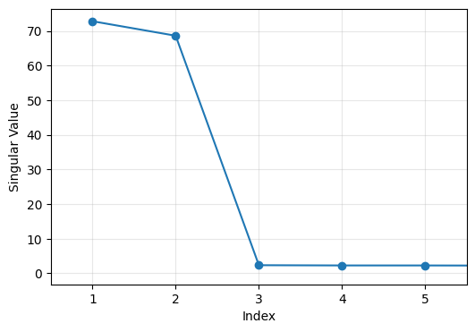

```python
plt.figure(figsize = (6, 4))
plt.plot(range(1, 101), S, 'o-')
plt.xticks(np.arange(6))
plt.xlim(0.5, 5.5)
plt.ylabel('Singular Value')
plt.xlabel('Index')
plt.grid(alpha = 0.3)
plt.show()
```

To achieve an efficient representation, we truncate the SVD by selecting only the top 2 singular values:

$$ y(x,t) \approx u_1(x)\sigma_1 v_1(t) + u_2(x)\sigma_2 v_2(t)$$

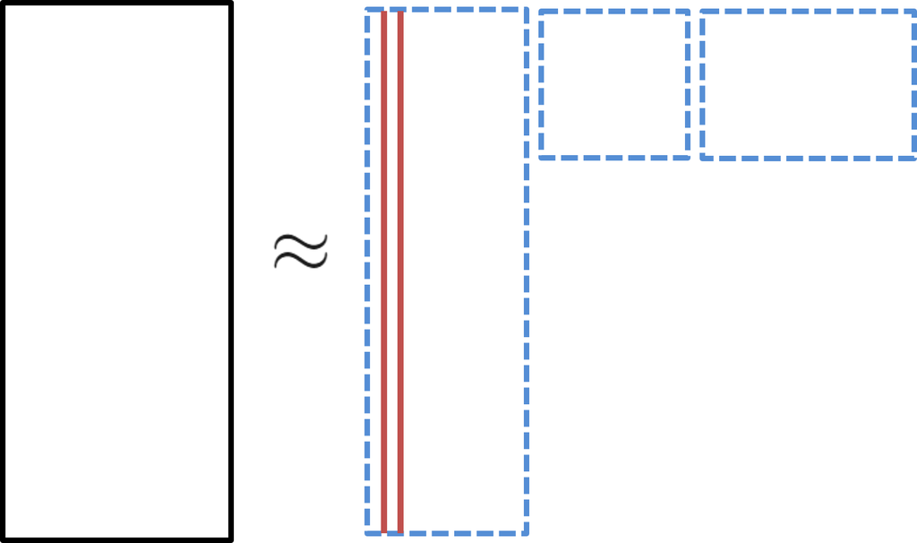

**Plot $u_1(x)$**

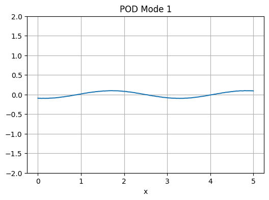

```python
plt.figure(figsize = (6, 4))
plt.plot(x, U[:,0])
plt.title('POD Mode 1')
plt.xlabel('x')
plt.ylim([-2, 2])
plt.grid()
plt.show()
```

**Plot $u_2(x)$**

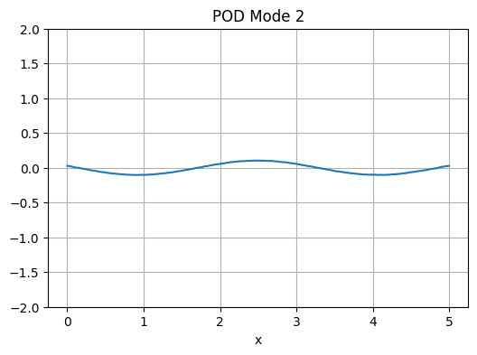

```python
plt.figure(figsize = (6, 4))
plt.plot(x, U[:,1])
plt.title('POD Mode 2')
plt.xlabel('x')
plt.ylim([-2, 2])
plt.grid()
plt.show()
```

$$\begin{align*} y(x,t) &\approx u_1(x)\sigma_1 v_1(t) + u_2(x)\sigma_2 v_2(t) \\ &\approx u_1(x)a_1(t) + u_2(x)a_2(t) \end{align*} $$

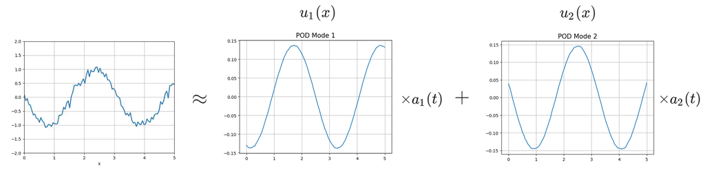

**Plot $a_1(t)$ and $a_2(t)$**

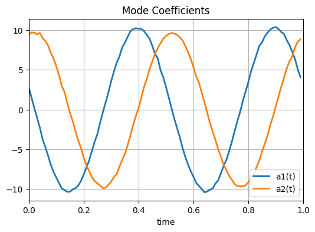

```python
plt.figure(figsize = (6, 4))
plt.plot(t, S[0]*VT[0,:], label = 'a1(t)', linewidth = 2)
plt.plot(t, S[1]*VT[1,:], label = 'a2(t)', linewidth = 2)
plt.xlim([0, 1])
plt.xlabel('time')
plt.title('Mode Coefficients')
plt.legend(loc = 4)
plt.grid()
plt.show()
```

**Low-Rank Approximation**

```python
U = np.asmatrix(U)
diagS = np.asmatrix(np.diag(S))
VT = np.asmatrix(VT)

print(U.shape, diagS.shape, VT.shape, '\n')

k = 2

low_U = U[:, :k]
low_S = diagS[:k, :k]
low_VT = VT[:k, :]

low_Y = low_U*low_S*low_VT

print(low_U.shape, low_S.shape, low_VT.shape, '\n')
```

```
(200, 100) (100, 100) (100, 100)

(200, 2) (2, 2) (2, 100)
```

```python
# Let's see the signal in time

from matplotlib.animation import FuncAnimation
import time
from IPython import display

fig = plt.figure(figsize = (6, 4))
ax1 = fig.add_subplot(1, 1, 1)

def animate(i):
  ax1.clear()
  ax1.plot(x, low_Y[:,i], linewidth = 2)
  ax1.set_xlim(0, 5)
  ax1.set_ylim(-2, 2)
  ax1.grid()

ani = FuncAnimation(fig, animate, frames = int(np.size(t)/1), interval = 10)
video = ani.to_html5_video()
html = display.HTML(video)
display.display(html)
plt.close()
```

[video not shown]

**Discussion**

The POD method effectively demonstrates its ability to extract meaningful patterns from data in a data-driven manner. The key outcomes and insights from this example are summarized below:

(1) Noise Reduction

- By retaining only the dominant modes in the decomposition, POD successfully filters out noise and reconstructs the underlying signal with improved clarity.
- This denoising capability arises naturally from the fact that noise typically resides in the smaller singular values, which are discarded during low-rank approximation.

(2) Data-Driven Decomposition

- This example illustrates that POD can effectively extract meaningful components without explicit knowledge of the underlying system dynamics. Specifically, POD decomposes the original signal into dominant spatial and temporal modes:

$$y(x,t) \approx u_1(x)a_1(t) + u_2(x)a_2(t)$$

Note: This data-driven decomposition closely aligns with the well-known trigonometric identity.

$$y(x,t) = \sin(\omega t - k x) = \sin(\omega t)\cos(-kx) + \cos(\omega t) \sin(-kx)$$

## 4.2. Example 2: Fluid Flow Past a Circular Cylinder at Low Reynolds Number

This example is adapted from the textbook "[Data-Driven Science and Engineering](https://databookuw.com/)" by [Steven L. Brunton](https://www.eigensteve.com/) and [J. Nathan Kutz](https://faculty.washington.edu/kutz/).

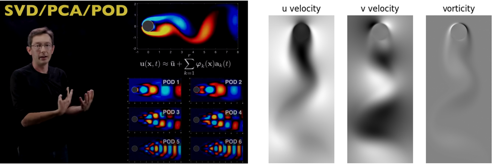

**Data Description and Visualization**

The dataset provided contains flow field data for fluid flow past a circular cylinder at a Reynolds number of Re = 100. The data file, [CYLINDER_ALL.mat](https://drive.google.com/file/d/1AbagAoYIfQo-1pjYRGZtzEIr-fMEM7EM/view?usp=sharing), includes 151 snapshots of velocity components and vorticity fields:

- UALL: Horizontal velocity field (u-velocity)
- VALL: Vertical velocity field (v-velocity)
- VORTALL: Vorticity field

The flow is studied at a Reynolds number of Re = 100, a regime where vortex shedding occurs periodically and can be captured effectively using low-rank approximations.

```python
from google.colab import drive
drive.mount('/content/drive')
```

```python
from scipy import io

flows = io.loadmat('/content/drive/MyDrive/ML/ML_data/CYLINDER_ALL.mat')
```

```python
flows_mat_u = flows['UALL']
flows_mat_v = flows['VALL']
flows_mat_vort = flows['VORTALL']

flows_mat_u.shape
```

```
(89351, 151)
```

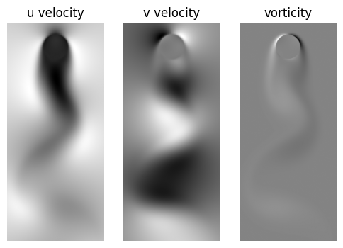

```python
nx = 449
ny = 199

plt.figure(figsize = (6, 4))
plt.subplot(1,3,1)
plt.imshow(flows_mat_u[:,150].reshape(nx, ny), 'gray')
plt.title('u velocity')
plt.axis('off')

plt.subplot(1,3,2)
plt.imshow(flows_mat_v[:,150].reshape(nx, ny), 'gray')
plt.title('v velocity')
plt.axis('off')

plt.subplot(1,3,3)
plt.imshow(flows_mat_vort[:,150].reshape(nx, ny), 'gray')
plt.title('vorticity')
plt.axis('off')

plt.show()
```

```python
# Let's see the flow in time

from matplotlib.animation import FuncAnimation
import time
from IPython import display

fig = plt.figure(figsize = (6, 4))
ax1 = fig.add_subplot(1, 3, 1)
ax2 = fig.add_subplot(1, 3, 2)
ax3 = fig.add_subplot(1, 3, 3)

def animate(i):
  ax1.clear()
  ax1.imshow(flows_mat_u[:,i].reshape(nx, ny), 'gray')
  ax1.set_title('u velocity')
  ax1.axis('off')
  ax2.clear()
  ax2.imshow(flows_mat_v[:,i].reshape(nx, ny), 'gray')
  ax2.set_title('v velocity')
  ax2.axis('off')
  ax3.clear()
  ax3.imshow(flows_mat_vort[:,i].reshape(nx, ny), 'gray')
  ax3.set_title('vorticity')
  ax3.axis('off')

ani = FuncAnimation(fig, animate, frames = int(150/1), interval = 10)
video = ani.to_html5_video()
html = display.HTML(video)
display.display(html)
plt.close()
```

[video not shown]

From now on, we will focus on vorticity rather than u and v velocity.

It is common practice to subtract the mean or equilibrium state for clearer analysis.

```python
flows_mat_vort_normalized = (flows_mat_vort - flows_mat_vort.min()) / (flows_mat_vort.max() - flows_mat_vort.min())

flows_mat_vort_normalized_mean = flows_mat_vort_normalized.mean(axis = 1)
flows_mat_vort_normalized_centered = flows_mat_vort_normalized - flows_mat_vort_normalized_mean[:, None]
```

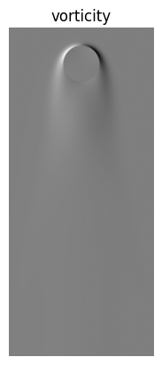

```python
plt.imshow(flows_mat_vort_normalized_mean.reshape(nx, ny), 'gray')
plt.title('vorticity')
plt.axis('off')
plt.show()
```

**Perform the POD**

```python
flows_mat = flows_mat_vort_normalized_centered

U, S, VT = np.linalg.svd(flows_mat, full_matrices = False)
print(U.shape)
print(S.shape)
print(VT.shape)
```

```
(89351, 151)
(151,)
(151, 151)
```

**Plot Singular Values**

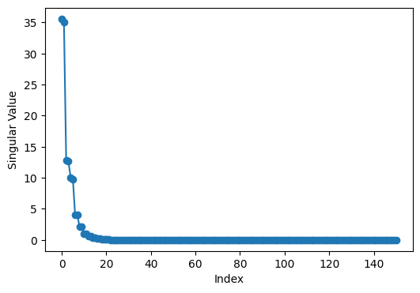

```python
plt.figure(figsize = (6, 4))
plt.plot(S, '-o')
plt.ylabel('Singular Value')
plt.xlabel('Index')
plt.show()
```

**Plot Several Spatial Modes**

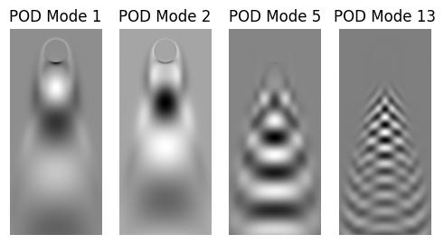

```python
plt.figure(figsize = (6, 4))

plt.subplot(1,4,1)
plt.imshow(U[:,0].reshape(nx, ny), 'gray')
plt.title('POD Mode 1')
plt.axis('off')

plt.subplot(1,4,2)
plt.imshow(U[:,1].reshape(nx, ny), 'gray')
plt.title('POD Mode 2')
plt.axis('off')

plt.subplot(1,4,3)
plt.imshow(U[:,4].reshape(nx, ny), 'gray')
plt.title('POD Mode 5')
plt.axis('off')

plt.subplot(1,4,4)
plt.imshow(U[:,12].reshape(nx, ny), 'gray')
plt.title('POD Mode 13')
plt.axis('off')

plt.show()
```

**Low Rank Approximation**

```python
k = 5

low_U = U[:, :k]
low_S = diagS[:k, :k]
low_VT = VT[:k, :]

print(low_U.shape, low_S.shape, low_VT.shape, '\n')

low_flows_mat = low_U*low_S*low_VT
```

```
(89351, 5) (5, 5) (5, 151)
```

```python
# Let's see the flow in time

from matplotlib.animation import FuncAnimation
import time
from IPython import display

fig = plt.figure(figsize = (6, 4))
ax1 = fig.add_subplot(1, 2, 1)
ax2 = fig.add_subplot(1, 2, 2)

def animate(i):
  ax1.clear()
  ax1.imshow(flows_mat[:,i].reshape(nx, ny) + flows_mat_vort_normalized_mean.reshape(nx, ny), 'gray')
  ax1.set_title('original')
  ax1.axis('off')
  ax2.clear()
  ax2.imshow(low_flows_mat[:,i].reshape(nx, ny) + flows_mat_vort_normalized_mean.reshape(nx, ny), 'gray')
  ax2.set_title('low rank')
  ax2.axis('off')

ani = FuncAnimation(fig, animate, frames = int(150/1), interval = 10)
video = ani.to_html5_video()
html = display.HTML(video)
display.display(html)
plt.close()
```

[video not shown]

**Discussion**

In this example, we apply POD to analyze the complex flow field dynamics of fluid flow past a circular cylinder at a Reynolds number of 100. This method effectively identifies dominant flow patterns and provides a low-dimensional representation of the system.

**Key Takeaway from Dimension Reduction**

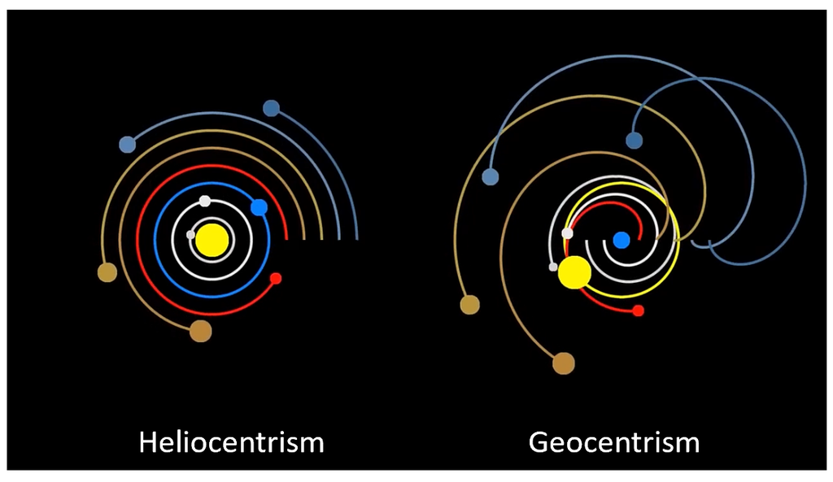

Just as the Heliocentric model simplified our understanding of planetary motion by shifting to a better reference frame, effective dimension reduction techniques reveal meaningful insights by aligning data with its most informative structure.

By finding the right transformation or new coordinate system, complex data can become self-explanatory, improving both interpretation and predictive power.

# 5. Fisher Discriminant Analysis (FDA)

```python
from IPython.display import YouTubeVideo
YouTubeVideo('4Pz3TDX5dBs', width = "560", height = "315")
```

[video not shown]

## 5.1. FDA Algorithm

### 5.1.1. Dimensionality Reduction with Label

In many machine learning tasks, dimensionality reduction is a crucial step for improving efficiency and enhancing model performance. While unsupervised methods such as Principal Component Analysis (PCA) effectively reduce dimensionality by maximizing variance, they do not take class labels into account. Consequently, PCA may overlook class-specific patterns that are important for classification or regression.

Fisher Discriminant Analysis (FDA) - also known as Linear Discriminant Analysis (LDA) - addresses this limitation by incorporating label information into the dimensionality reduction process. Unlike PCA, FDA aims to project the data onto a lower dimensional space that maximizes class separability.

**Key Characteristics of PCA and FDA**

Principal Component Analysis (PCA)

- Focuses solely on maximizing data variance.
- Does not utilize class label information.
- Reduces dimensionality by selecting directions that capture the largest variability in the data.

Fisher Discriminant Analysis (FDA)

- Uses class label information to find optimal projection directions.
- Ensures that data points from the same class are projected close together.
- Projects data points from different classes far apart to improve class separability.

**Core Objective of FDA**

FDA seeks to achieve two primary objectives simultaneously:

(1) Minimize Within-Class Variance:

- FDA ensures that samples belonging to the same class are projected close together.
- This is achieved by minimizing the spread of data points within each class.

(2) Maximize Between-Class Variance:

- FDA aims to position samples from different classes as far apart as possible.
- This is achieved by maximizing the distance between class means.

In this sense, FDA provides a supervised dimensionality reduction method that emphasizes class separation, making it particularly suitable for tasks such as classification.

### 5.1.2. Projection onto Line $\omega$

In Fisher Discriminant Analysis (FDA), the goal is to project high-dimensional data onto a one-dimensional space (a line) in such a way that maximizes class separation.

Suppose each data point $x$ is a two-dimensional vector:

$$x = \begin{bmatrix}x_1 \\ x_2 \end{bmatrix}$$

For simplicity, we assume the data is zero mean. If not, data should be centered:

$$x \leftarrow x - \bar{x}$$

Each data point is projected onto a line defined by the vector $\omega$. The projection is computed as:

$$ \hat{y} = \langle \omega,x\rangle = \omega^Tx = \omega_1x_1 + \omega_2x_2$$

Here, $\hat y$ is a scalar value representing the projected data point on the line.

The original data point $x$ in two dimensions is transformed into the scalar $\hat y$, which is a lower-dimensional representation:

$$x = \begin{bmatrix}x_1 \\ x_2 \end{bmatrix} \quad \rightarrow \quad \hat y \; (\text{scalar})$$

Each data point $x$ is projected onto the line defined by $\omega$, with the projected length along the $\omega$-direction serving as the new data point.

The set of projected points:

$$\{ \hat y^{(1)}, \cdots, \hat y^{(m)} \}$$

represents the distribution of data points in the new one-dimensional space.

**Key Question: Which $\omega$ is better for classification?**

- The choice of $\omega$ significantly impacts the effectiveness of the projection for separating classes.
- An optimal $\omega$ should maximize the separation between classes while minimizing the spread of points within each class.

In Fisher Discriminant Analysis, the optimal $\omega$ is selected to achieve this balance by maximizing the between-class variance and minimizing the within-class variance - a concept explored in the subsequent sections.

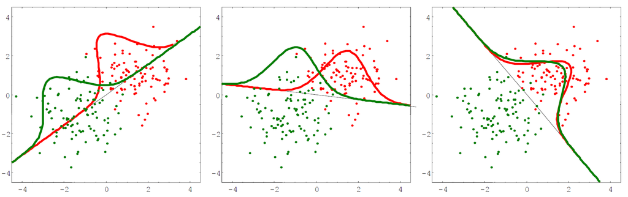

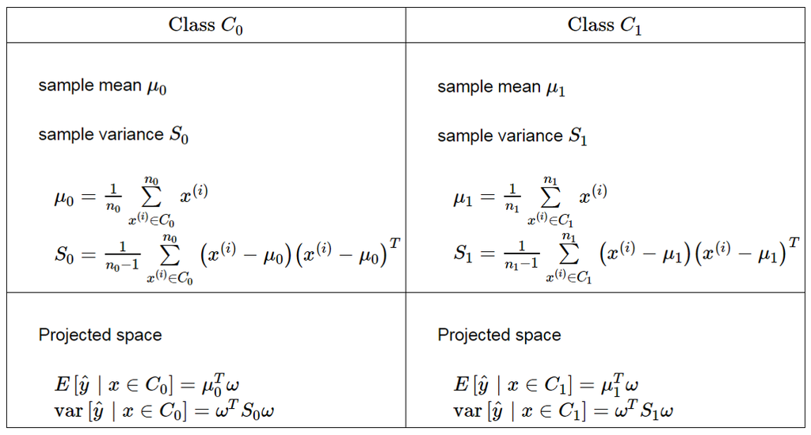

### 5.1.3. Fisher Discriminant Analysis

The goal of FDA is to find a direction $\omega$ such that:

- The distance between class means (when projected onto $\omega$) is maximized.
- The variance within each class (when projected onto $\omega$) is minimized.

To achieve this, FDA maximizes the following ratio:

$$\max_\omega \frac{(\text{seperation of projected means})^2}{\text{sum of within class variances}}$$

Equivalently,

$$ \implies \max_\omega \frac {\big(\mu_0^T\omega - \mu_1^T\omega \big)^2}{n_0\omega^TS_0\omega + n_1\omega^TS_1\omega}$$

Where:

- $\mu_0$ and $\mu_1$ are the mean vectors for Class 0 and Class 1, respectively.
- $n_0$ and $n_1$ are the number of samples in each class.
- $S_0$ and $S_1$ are the within-class scatter matrices, which measure the variance of each class.

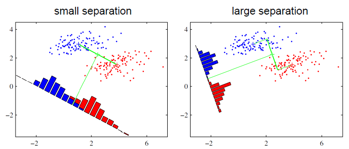

We aim to find the optimal projection vector $\omega$ that maximizes class separation.

**Step 1: Objective Function**

The objective is to maximize the following ratio:

$$\omega^* = \text{arg}\max_\omega \bigg\{ \frac{\big((\mu_0^T - \mu_1^T)\omega\big)^2}{n_0\omega^TS_0\omega + n_1\omega^TS_1\omega} \bigg \}$$

By defining:

- $m \equiv \mu_0 - \mu_1$: the difference between class means
- $\Sigma \equiv n_0S_0 + n_1S_1 = R^TR$: the combined within-class scatter matrix

We rewrite the objective as:

$$J(\omega) = \frac {\big((\mu_0^T - \mu_1^T)\omega\big)^2}{\omega^T(n_0S_0 + n_1S_1)\omega} = \frac {(m^T\omega)^2}{\omega^T\Sigma \omega}$$

**Step 2: Coordinate Transformation**

Since $ \Sigma $ is symmetric and positive semi-definite, we can factorize it as $ \Sigma = R^T R $, where $ R $ is a square root matrix.

Now introduce a new variable $ u $ such that:

$$u = R\omega \quad \Rightarrow \quad \omega = R^{-1}u$$

This change of variables simplifies the objective function:

$$J(u) = \frac {\big( m^TR^{-1}u\big)^2}{\omega^TR^TR\omega} = \frac{\left( m^T R^{-1} u \right)^2}{u^T u}$$

**Step 3: Maximizing the Objective**

Since $ u^T u = \lVert u \rVert^2 $, the objective becomes:

$$J(u) = \left( \left( R^{-T} m \right)^T \frac{u}{\lVert u \rVert} \right)^2 = { \left \langle R^{-T} m, \frac{u}{\lVert u \rVert} \right \rangle}^2$$

By the properties of the dot product, this expression is maximized when:

$$u = a R^{-T} m$$

Why?:

Dot product of a unit vector and another vector is maximum when the two have the same direction.

**Step 4: Recovering $ \omega $**

By substituting back the relationship $ \omega = R^{-1} u $:

$$\omega = a R^{-1} R^{-T} m$$

Since $ R^{-1} R^{-T} = \Sigma^{-1} $, we have:

$$\omega = a \Sigma^{-1} m$$

By substituting back $ m = \mu_0 - \mu_1 $ and $ \Sigma = n_0S_0 + n_1S_1 $, the final solution is:

$$\omega = a (n_0S_0 + n_1S_1)^{-1} (\mu_0 - \mu_1)$$

This result highlights FDA's ability to effectively combine dimensionality reduction and classification by maximizing class separation.

## 5.2. FDA in Python

```python
import numpy as np
import matplotlib.pyplot as plt
%matplotlib inline
```

**Data Generation**

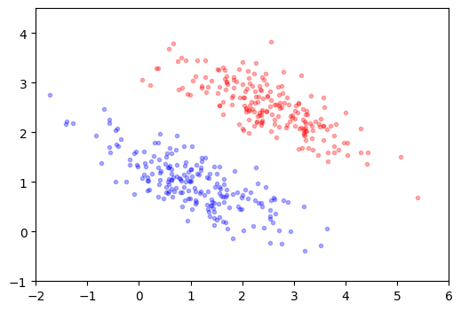

```python
# generating data set

n0 = 200
n1 = 200

mu = [0, 0]
sigma = [[0.9, -0.4],
         [-0.4, 0.3]]

np.random.seed(42)
x0 = np.random.multivariate_normal([2.5,2.5], sigma, n0).T        # data in class 0
x1 = np.random.multivariate_normal([1,1], sigma, n1).T            # data in class 1

x0 = np.asmatrix(x0)
x1 = np.asmatrix(x1)

plt.figure(figsize = (6, 4))
plt.plot(x0[0,:], x0[1,:], 'r.', alpha = 0.3)
plt.plot(x1[0,:], x1[1,:], 'b.', alpha = 0.3)
plt.xlim([-2, 6])
plt.ylim([-1, 4.5])
plt.show()
```

Before determining the optimal $ \omega $, it is helpful to examine how the distribution of projected data points varies depending on different projection directions.

Consider the line represented by the equation:

$$\omega_1 x_1 + \omega_2 x_2 = 0$$

By observing the projected points along these different lines, we can gain insight into how the choice of $ \omega $ influences class separation and data spread. This visualization helps build intuition before proceeding to identify the optimal $ \omega $.

**Projection onto x-axis**

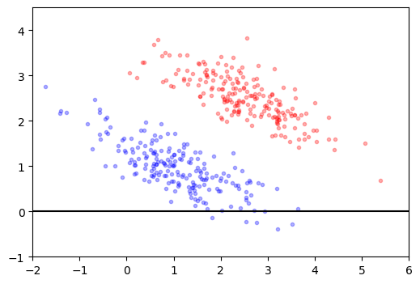

```python
# x-axis

w = np.array([[1], [0]])
w = np.asmatrix(w)

plt.figure(figsize = (6, 4))
plt.plot(x0[0,:], x0[1,:], 'r.', alpha = 0.3)
plt.plot(x1[0,:], x1[1,:], 'b.', alpha = 0.3)
plt.axhline(0, color = 'k')
plt.xlim([-2, 6])
plt.ylim([-1, 4.5])
plt.show()
```

**Histogram of prejected data**

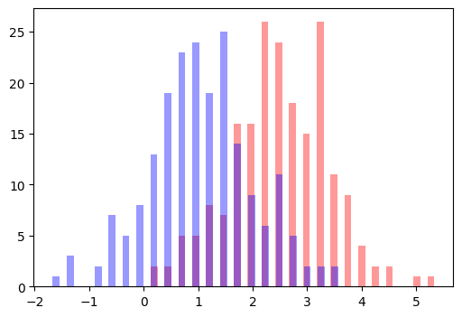

```python
y1 = x0.T*w
y2 = x1.T*w

plt.figure(figsize = (6, 4))
plt.hist(y1, 21, color = 'r', rwidth = 0.5, alpha = 0.4)
plt.hist(y2, 21, color = 'b', rwidth = 0.5, alpha = 0.4)
plt.show()
```

**Projection onto y-axis**

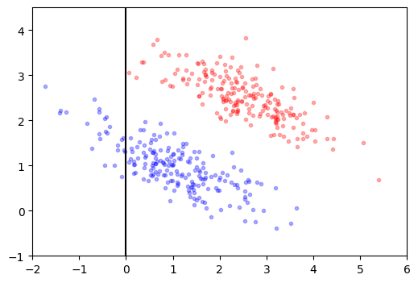

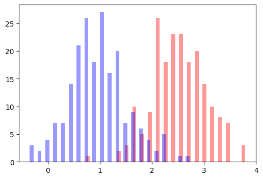

```python
# y-axis

w = np.array([[0], [1]])
w = np.asmatrix(w)

plt.figure(figsize = (6, 4))
plt.plot(x0[0,:], x0[1,:], 'r.', alpha = 0.3)
plt.plot(x1[0,:], x1[1,:], 'b.', alpha = 0.3)
plt.axvline(0, color = 'k')
plt.xlim([-2, 6])
plt.ylim([-1, 4.5])
plt.show()

y1 = x0.T*w
y2 = x1.T*w

plt.figure(figsize = (6, 4))
plt.hist(y1, 21, color = 'r', rwidth = 0.5, alpha = 0.4)
plt.hist(y2, 21, color = 'b', rwidth = 0.5, alpha = 0.4)
plt.show()
```

From both cases, we can observe that there is overlap in their histograms, which leads to potential misclassification when the data is projected into a lower-dimensional space.

Now, let's examine the optimal projection line determined by Fisher Discriminant Analysis (FDA) and analyze the corresponding distribution of projected data to evaluate its effectiveness in improving classification performance.

**Projection line by FDA**

```python
mu0 = np.mean(x0, axis = 1)
mu1 = np.mean(x1, axis = 1)

S0 = 1/(n0 - 1)*(x0 - mu0)*(x0 - mu0).T
S1 = 1/(n1 - 1)*(x1 - mu1)*(x1 - mu1).T

w = (n0*S0 + n1*S1).I*(mu0 - mu1)
print(w)
```

```
[[0.02425817]
 [0.04626859]]
```

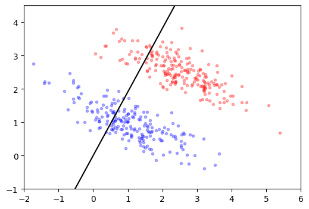

```python
plt.figure(figsize = (6, 4))
plt.plot(x0[0,:], x0[1,:], 'r.', alpha = 0.3)
plt.plot(x1[0,:], x1[1,:], 'b.', alpha = 0.3)

xp = np.arange(-4, 6, 0.1)
yp = w[1,0]/w[0,0]*xp
plt.plot(xp, yp, 'k')
plt.xlim([-2, 6])
plt.ylim([-1, 4.5])
plt.show()
```

**Histogram**

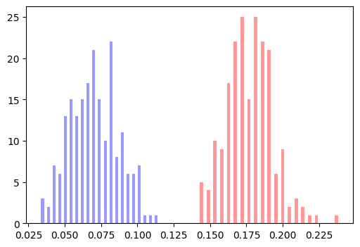

```python
y1 = x0.T*w
y2 = x1.T*w

plt.figure(figsize = (6, 4))
plt.hist(y1, 21, color = 'r', rwidth = 0.5, alpha = 0.4)
plt.hist(y2, 21, color = 'b', rwidth = 0.5, alpha = 0.4)
plt.show()
```

**Scikit-learn**

```python
# reshape data

X = np.vstack([x0.T, x1.T])
y = np.vstack([np.ones([n0, 1]), np.zeros([n1, 1])])
```

```python
from sklearn import discriminant_analysis

X = np.array(X)

clf = discriminant_analysis.LinearDiscriminantAnalysis()
clf.fit(X, np.ravel(y))
```

```
LinearDiscriminantAnalysis()
```

**Histogram**

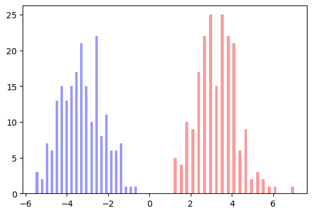

```python
# projection

X_LDA = clf.transform(X)

plt.figure(figsize = (6, 4))
plt.hist(X_LDA[0:200], 21, color = 'r', rwidth = 0.5, alpha = 0.4)
plt.hist(X_LDA[200:400], 21, color = 'b', rwidth = 0.5, alpha = 0.4)
plt.show()
```

**Classification boundary**

```python
# classifier boundary, not a projection line

clf_w = clf.coef_[0]
clf_w0 = clf.intercept_[0]
print(clf_w)
print(clf_w0)
```

```
[ 9.70326866 18.50743511]
-49.45561208450006
```

**Projection line**

```python
# projection line

mu0 = np.mean(x0, axis = 1)
mu1 = np.mean(x1, axis = 1)

S0 = 1/(n0 - 1)*(x0 - mu0)*(x0 - mu0).T
S1 = 1/(n1 - 1)*(x1 - mu1)*(x1 - mu1).T

prj_w = (n0*S0 + n1*S1).I*(mu0 - mu1)
```

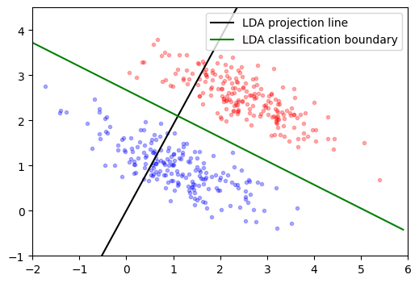

```python
xp = np.arange(-4, 6, 0.1)
prj_yp = prj_w[1,0]/prj_w[0,0]*xp
clf_yp = - clf_w[0]/clf_w[1]*xp - clf_w0/clf_w[1]

plt.figure(figsize = (6, 4))
plt.plot(x0[0,:], x0[1,:], 'r.', alpha = 0.3)
plt.plot(x1[0,:], x1[1,:], 'b.', alpha = 0.3)
plt.plot(xp, prj_yp, 'k', label = 'LDA projection line')
plt.plot(xp, clf_yp, 'g', label = 'LDA classification boundary')
plt.legend()
plt.xlim([-2, 6])
plt.ylim([-1, 4.5])
plt.show()
```

We have studied Fisher Discriminant Analysis (FDA), exploring both its theoretical foundation and practical implementation. While FDA facilitates dimensionality reduction, it is important to emphasize that FDA operates in a supervised manner. Unlike unsupervised methods such as PCA, the primary objective of FDA is not merely to reduce dimensionality but to achieve effective class separation and improve classification performance.

```python
%%javascript
$.getScript('https://kmahelona.github.io/ipython_notebook_goodies/ipython_notebook_toc.js')
```